# GeneSetCluster

Ewoud Ewing

06/05/2019

# 1 GeneSetCluster Package example data

This is the demonstration of the R package GeneSetCluster

This is a package meant to be used to cluster together Gene-Sets from pathway tools such as Ingenuity Pathway Aanalysis (IPA) (https://www.qiagenbioinformatics.com/products/ingenuity-pathway-analysis/) and GREAT (http://great.stanford.edu/public/html/index.php), GSEA (http://software.broadinstitute.org/gsea/index.jsp) and others. Gene-Sets often appear significant when running such tools with different labels displaying different Gene-Sets.

Sometimes, interpreting the output is difficult, which can be made worse whenof several gene sets analysis are compared.

The output data has several limitations: 1) Low ratio: where there are only a few genes enriched.

2. High similarity: where the different genes sets that appear have the same genes enriched despite the different labels.
3. Low overlap: where the same gene set labels appear in different experimental settings but different genes are enriched.

Consequently, it is preferable to review the gene set analysis experiment as a whole instead of investigating the many different Gene-Sets individually. Furthermore, analysing multiple gene set analysis is also improved by combining the different experiments. This package does this by taking the sets of genes of every Gene-Set and calculates the distance between them. By default this package uses a relative risk, the higher it is the greater overlap they have. This distance score is then used to cluster the Gene-Sets together.

Example data is taken from https://www.ncbi.nlm.nih.gov/geo/query/acc.cgi?acc=GSE111385

Data has been analysed with Deseq2 pipeline where the data is Transcriptome sequencing of WT and conditional-Tgfbr2 knockout microglia and CNS-repopulating monocyte-derived macrophages from C57BL/6 mouse in triplicates. The genes were picked in a comparison of uG vs Mac in both WT and KO with a 1E-06 pvalue cutoff. Genes were analysed in both IPA with the Canonical pathways and functional annotations were exported into a excel file with default settings. Bed files were also generated for the genes, and uploaded in GREAT with a background of the sequencing samples. All data was exported in tsv format.

## 1.1 Pipeline

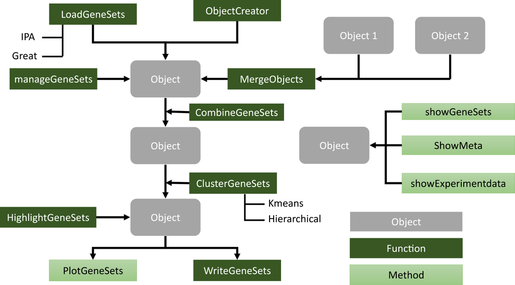

Pipeline of the Package

## 1.2 Loading the data

The LoadGeneSets function has all this automated, currently the LoadGeneSets function supports loading GREAT TSV files (As exported as “all data as TSV”).

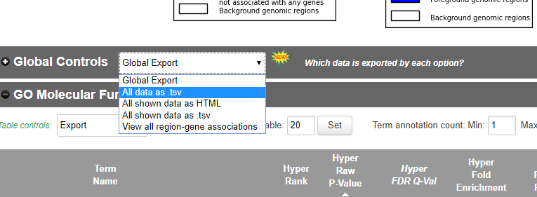

As well as IPA canonical pathways (exported as excel) or Functional annotations (exported as excel).

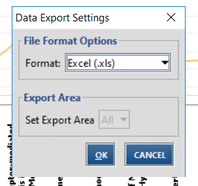

exporting IPA

While exporting the dat afrom GREAT or IPA the data is not filtered, there for the loader filters the data. It needs a Pvalue cutoff. In IPA the pvalue in Canonical Pathways is given as a -log10 pvalue, if the P.cutoff is larger than 1 the loader assumes that the pvalues are -log10 transformed. The minimum number of genes (or molecules) per Gene-Set (Recommended >= 5), the data source. If GREAT was run the program needs to know wether GREAT was run with a background. The type of data (Canonical Pathways, Functional analysis etc). for GREAT doenst matter as it runs 18 diferent types that the loader automatically assigns.

The GREAT output is really really large, so the tool itself by default displays the top 20 ranks, this can be emulated by using the topranks. The structure e.g. SYMBOL, this is important as the combinePathways check that all the data is in the same structure and convert if neccesary, which is why it needs the Organism. Currently supported is the org.Mm.eg.db and org.Hs.eg.db packages. Last but not least is the seperator, for seperating the genes from the string.

Note the package suitable for 1 gene set analysis as well as multiple. To load 1 experiment, link to the file using file_location and supply just 1 groupnames. For multiple experiments use more than 1.

## 1.3 Loading GREAT

### 1.3.1 Loading GREAT data

```r
Great.files <- c(system.file("extdata", "MM10.GREAT.KO.uGvsMac.bed.tsv", package = "GeneSetCluster"),
                 system.file("extdata", "MM10.GREAT.KO.uGvsMac.bed_BCKGRND.tsv", package = "GeneSetCluster"),
                 system.file("extdata", "MM10.GREAT.WT.uGvsMac.bed.tsv", package = "GeneSetCluster"),
                 system.file("extdata", "MM10.GREAT.WT.uGvsMac.bed_BCKGRND.tsv", package = "GeneSetCluster"))
Great.files.bckgrnd <- Great.files[grepl("BCKGRND", Great.files)]


Great.bckgnrd.Object1 <- LoadGeneSets(file_location = Great.files.bckgrnd,
                              groupnames= c("KO", "WT"),
                              P.cutoff = 0.05,
                              Mol.cutoff = 5,
                              Source = "Great",
                              Great.Background = T,
                              type = "Canonical_Pathways",
                              topranks = 20,
                              structure = "SYMBOL",
                              Organism = "org.Mm.eg.db",
                              seperator = ",")
```

```
## [=========================================================]
```

```
## [<<<<            LoadGeneSets START                  >>>>>]
```

```
## Loading data from C:/Users/ewoewi/Documents/Project9/Paper/GeneSetCluster/GeneSetCluster_1.0.1/GeneSetCluster/inst/extdata/MM10.GREAT.KO.uGvsMac.bed_BCKGRND.tsv
```

```
## Loading data from C:/Users/ewoewi/Documents/Project9/Paper/GeneSetCluster/GeneSetCluster_1.0.1/GeneSetCluster/inst/extdata/MM10.GREAT.WT.uGvsMac.bed_BCKGRND.tsv
```

```
## Loading Splitting Great types passing cutoff
```

```
## [<<<<<               LoadGeneSets END               >>>>>>]
```

```
## [=========================================================]
```

```
## [You may want to process CombineGeneSets next.            ]
```

```
## [or merge objects using MergeObjects                     ]
```

```
## [or select certain types from objects using ManageGeneSets]
```

### 1.3.2 Plot Overlap of Gene-Sets labels

Recommende is to inspect the labels, if there are multiple experiments the labels can be compared.

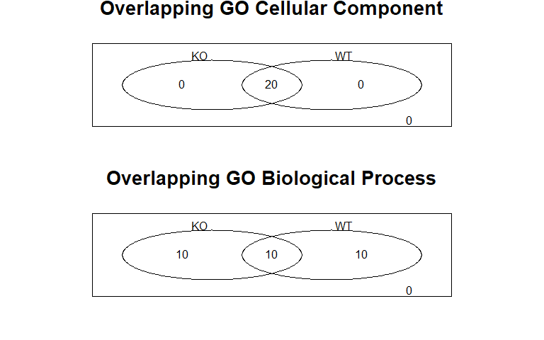

### 1.3.3 Investigate the metafiles

Check the experiment data and the metainfo to make sure that the PathwayObject matches your experiment(s).

```r
ShowExperimentdata(Object =Great.bckgnrd.Object1 )
```

```
##              Groupnames Length
## Experiment_1         KO     20
## Experiment_2         KO     20
## Experiment_3         KO     14
## Experiment_4         WT     20
## Experiment_5         WT     20
## Experiment_6         WT     20
##                                                                                                                                               file_location
## Experiment_1 C:/Users/ewoewi/Documents/Project9/Paper/GeneSetCluster/GeneSetCluster_1.0.1/GeneSetCluster/inst/extdata/MM10.GREAT.KO.uGvsMac.bed_BCKGRND.tsv
## Experiment_2 C:/Users/ewoewi/Documents/Project9/Paper/GeneSetCluster/GeneSetCluster_1.0.1/GeneSetCluster/inst/extdata/MM10.GREAT.KO.uGvsMac.bed_BCKGRND.tsv
## Experiment_3 C:/Users/ewoewi/Documents/Project9/Paper/GeneSetCluster/GeneSetCluster_1.0.1/GeneSetCluster/inst/extdata/MM10.GREAT.KO.uGvsMac.bed_BCKGRND.tsv
## Experiment_4 C:/Users/ewoewi/Documents/Project9/Paper/GeneSetCluster/GeneSetCluster_1.0.1/GeneSetCluster/inst/extdata/MM10.GREAT.WT.uGvsMac.bed_BCKGRND.tsv
## Experiment_5 C:/Users/ewoewi/Documents/Project9/Paper/GeneSetCluster/GeneSetCluster_1.0.1/GeneSetCluster/inst/extdata/MM10.GREAT.WT.uGvsMac.bed_BCKGRND.tsv
## Experiment_6 C:/Users/ewoewi/Documents/Project9/Paper/GeneSetCluster/GeneSetCluster_1.0.1/GeneSetCluster/inst/extdata/MM10.GREAT.WT.uGvsMac.bed_BCKGRND.tsv
```

```r
ShowMeta(Object = Great.bckgnrd.Object1 )
```

```
##              source                  type structure     organism Groups
## Experiment_1  Great GO Biological Process    SYMBOL org.Mm.eg.db     KO
## Experiment_2  Great GO Cellular Component    SYMBOL org.Mm.eg.db     KO
## Experiment_3  Great GO Molecular Function    SYMBOL org.Mm.eg.db     KO
## Experiment_4  Great GO Biological Process    SYMBOL org.Mm.eg.db     WT
## Experiment_5  Great GO Cellular Component    SYMBOL org.Mm.eg.db     WT
## Experiment_6  Great GO Molecular Function    SYMBOL org.Mm.eg.db     WT
##              seperator Data cluster.method highlight order.group loaded
## Experiment_1         , List             NA        NA          NA   Auto
## Experiment_2         , List             NA        NA          NA   Auto
## Experiment_3         , List             NA        NA          NA   Auto
## Experiment_4         , List             NA        NA          NA   Auto
## Experiment_5         , List             NA        NA          NA   Auto
## Experiment_6         , List             NA        NA          NA   Auto
##                display mol.signature
## Experiment_1 Condensed           All
## Experiment_2 Condensed           All
## Experiment_3 Condensed           All
## Experiment_4 Condensed           All
## Experiment_5 Condensed           All
## Experiment_6 Condensed           All
```

### 1.3.4 Manage Gene-Sets

Following loading of the PathwayObject the distance can be calculated in the combinePathway function. If the data is very large, data can be managed by selecting for types of interest using ManageGeneSets In this example we are interested in Disease Ontology and Go Biological Process, so we ManageGeneSets to keep those data types and remove the others. The result of the ManageGeneSets we can see using ShowExperimentdata and ShowMeta.

```r
man.Great.Object1 <- ManageGeneSets(Object = Great.bckgnrd.Object1, keep.type =c("Disease Ontology","GO Biological Process" ), exclude.type="")
```

```
## [=========================================================]
```

```
## [<<<<<             ManageGeneSets start             >>>>>>]
```

```
## Keeping the following pathways types:
```

```
## Disease Ontology
```

```
## GO Biological Process
```

```
## [<<<<<             ManageGeneSets END               >>>>>>]
```

```
## [=========================================================]
```

```r
ShowExperimentdata(Object =man.Great.Object1 )
```

```
##              Groupnames Length
## Experiment_1         KO     20
## Experiment_4         WT     20
##                                                                                                                                               file_location
## Experiment_1 C:/Users/ewoewi/Documents/Project9/Paper/GeneSetCluster/GeneSetCluster_1.0.1/GeneSetCluster/inst/extdata/MM10.GREAT.KO.uGvsMac.bed_BCKGRND.tsv
## Experiment_4 C:/Users/ewoewi/Documents/Project9/Paper/GeneSetCluster/GeneSetCluster_1.0.1/GeneSetCluster/inst/extdata/MM10.GREAT.WT.uGvsMac.bed_BCKGRND.tsv
```

```r
ShowMeta(Object =man.Great.Object1 )
```

```
##              source                  type structure     organism Groups
## Experiment_1  Great GO Biological Process    SYMBOL org.Mm.eg.db     KO
## Experiment_4  Great GO Biological Process    SYMBOL org.Mm.eg.db     WT
##              seperator Data cluster.method highlight order.group loaded
## Experiment_1         , List             NA        NA          NA   Auto
## Experiment_4         , List             NA        NA          NA   Auto
##                display mol.signature
## Experiment_1 Condensed           All
## Experiment_4 Condensed           All
```

### 1.3.5 Combine and cluster

Following all the setup of the pathwayObject we can now combine and cluster the Gene-Sets. The CombineGeneSets function calculates the distance between Gene-Sets which is further used for clustering. The distance by default is a Relative Risk (RR), however if desired a user supplied functuon can also be provided (see 1.4.6). The clustering can be done in 4 ways, kmeans, Kmeans per group, hierarchical, and hierarchical per group. depending on the data different clustering methods work better. As for how many clusters your data requires, is depended on your data. It is recommended that you use a trial and error approach to detereming the optimal number of clusters.

Combine object gives you the option to display a condensed version of the data or an expanded one with groups being compared or seperated. ClusterGeneSets furthermore gives you the option to filter for unique molecular signatures. This can be usefull for experiments where the same gene signature appears a lot.

Advised is to not filter for unique molecular signature when the display is set to Condensed. This will lead to a loss of information. Advised is to set display to Expanded before filtering for unique molecular signatures.

```r
man.Great.Object2 <- CombineGeneSets(Object = man.Great.Object1,
                                     combineMethod = "Standard",
                                     display = "condensed")
```

```
## [=========================================================]
```

```
## [<<<<            CombineGeneSets START               >>>>>]
```

```
## transforming all genes to upper case, make sure this doesnt change the data
```

```
## raw data has 2568 genes
```

```
## Transformed data has 2568 genes
```

```
## Combining experiments
```

```
## preparing condensed display
```

```
## calulating RR
```

```
## [<<<<<             CombineGeneSets END              >>>>>>]
```

```
## [=========================================================]
```

```
## [You may want to process ClusterGeneSets next.            ]
```

```r
man.Great.Object3 <- ClusterGeneSets(Object = man.Great.Object2,
                                 clusters = 5,
                                 method = "kmeans",
                                 order = "cluster",
                                 molecular.signature = "All")
```

```
## [=========================================================]
```

```
## [<<<<            ClusterGeneSets START               >>>>>]
```

```
## Using all Gene sets
```

```
## Running kmeans
```

```
## Ordering pathway clusters
```

```
## [<<<<<             ClusterGeneSets END              >>>>>>]
```

```
## [=========================================================]
```

```
## [You may want to process HighlightGeneSets next.            ]
```

```
## [You may want to plot the results using PlotGeneSets next. ]
```

```r
man.Great.Object2.expanded <- CombineGeneSets(Object = man.Great.Object1,
                                     combineMethod = "Standard",
                                     display = "Expanded")
```

```
## [=========================================================]
```

```
## [<<<<            CombineGeneSets START               >>>>>]
```

```
## transforming all genes to upper case, make sure this doesnt change the data
```

```
## raw data has 2568 genes
```

```
## Transformed data has 2568 genes
```

```
## Combining experiments
```

```
## preparing expanded display
```

```
## calulating RR
```

```
## [<<<<<             CombineGeneSets END              >>>>>>]
```

```
## [=========================================================]
```

```
## [You may want to process ClusterGeneSets next.            ]
```

```r
man.Great.Object3.expanded <- ClusterGeneSets(Object = man.Great.Object2.expanded,
                                 clusters = 5,
                                 method = "kmeans",
                                 order = "cluster",
                                 molecular.signature = "All")
```

```
## [=========================================================]
```

```
## [<<<<            ClusterGeneSets START               >>>>>]
```

```
## Using all Gene sets
```

```
## Running kmeans
```

```
## Ordering pathway clusters
```

```
## [<<<<<             ClusterGeneSets END              >>>>>>]
```

```
## [=========================================================]
```

```
## [You may want to process HighlightGeneSets next.            ]
```

```
## [You may want to plot the results using PlotGeneSets next. ]
```

### 1.3.6 Plot The great RR with background clusters

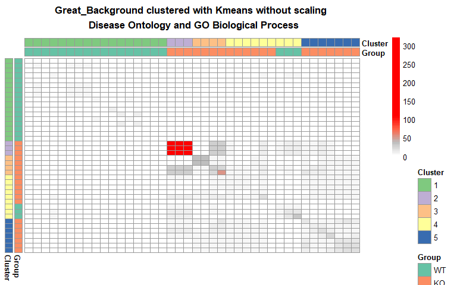

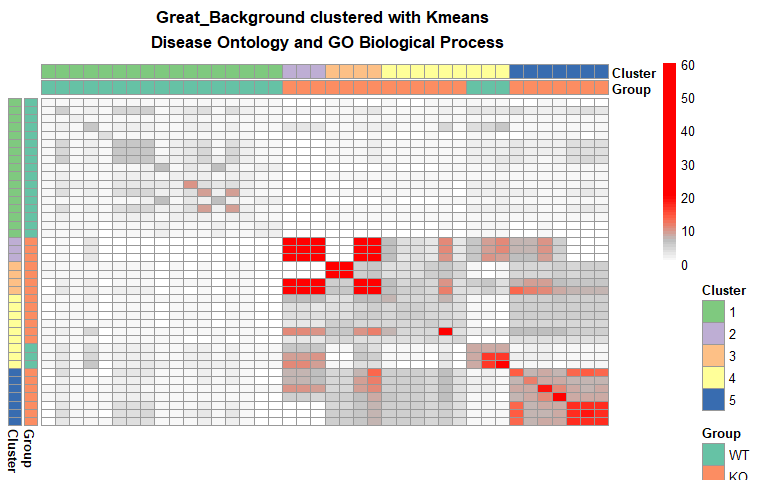

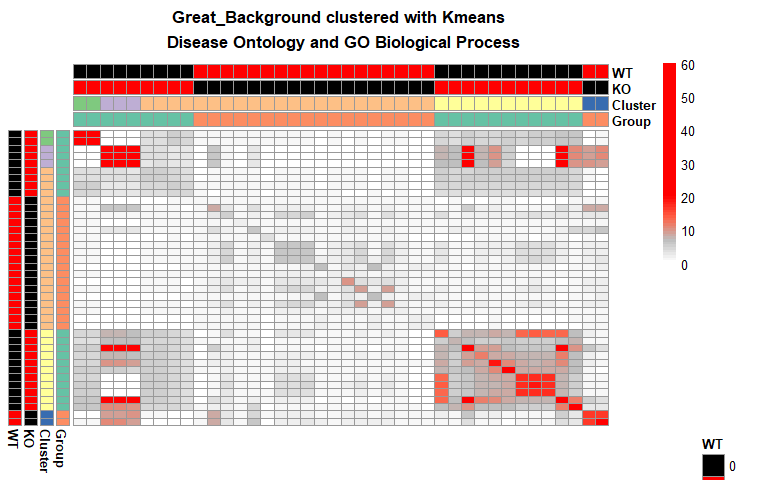

At the moment there is no plugin to deterermine the optimal number of clusters, therefor the user is advised to run several numbers of clusters to determine the optimal, e.g. a loop with different number of clusters plotted into a pdf.

## 1.4 IPA

### 1.4.1 Loading IPA data

When Loading IPA data we seperate between Canonical Pathways and Functional Anotations, as the source files have a different structure.

```r
IPA.files <- c(system.file("extdata", "MM10.IPA.KO.uGvsMac.Canonical_pathways.xls", package = "GeneSetCluster"),
                 system.file("extdata", "MM10.IPA.WT.uGvsMac.Canonical_pathways.xls", package = "GeneSetCluster"),
                 system.file("extdata", "MM10.IPA.KO.uGvsMac.Functional_annotations.xls", package = "GeneSetCluster"),
                 system.file("extdata", "MM10.IPA.WT.uGvsMac.Functional_annotations.xls", package = "GeneSetCluster"))
canonical.files <- IPA.files[grep("Canonical", IPA.files)]

IPA.object1 <- LoadGeneSets(file_location = canonical.files,
                            groupnames= c("Canonical.KO", "Canonical.WT"),
                            P.cutoff = 1.3,
                            Mol.cutoff = 5,
                            Source = "IPA",
                            type = "Canonical_Pathways",
                            structure = "SYMBOL",
                            seperator = ",")
```

```
## [=========================================================]
```

```
## [<<<<            LoadGeneSets START                  >>>>>]
```

```
## Loading data from C:/Users/ewoewi/Documents/Project9/Paper/GeneSetCluster/GeneSetCluster_1.0.1/GeneSetCluster/inst/extdata/MM10.IPA.KO.uGvsMac.Canonical_pathways.xls
```

```
## Loading data from C:/Users/ewoewi/Documents/Project9/Paper/GeneSetCluster/GeneSetCluster_1.0.1/GeneSetCluster/inst/extdata/MM10.IPA.WT.uGvsMac.Canonical_pathways.xls
```

[output not shown]

```
## Loading IPA Canonical_Pathways
```

```
## [<<<<<               LoadGeneSets END               >>>>>>]
```

```
## [=========================================================]
```

```
## [You may want to process CombineGeneSets next.            ]
```

```
## [or merge objects using MergeObjects                     ]
```

```
## [or select certain types from objects using ManageGeneSets]
```

### 1.4.2 Plot Overlap of pathway labels

Using the VennDiagram it is possible to see the overlap between the different labels in the IPA canonical output.

Nearly all the labels from KO are in the WT experiment. Nonetheless the labels are not as important as the genes which cause this gene set to be enriched.

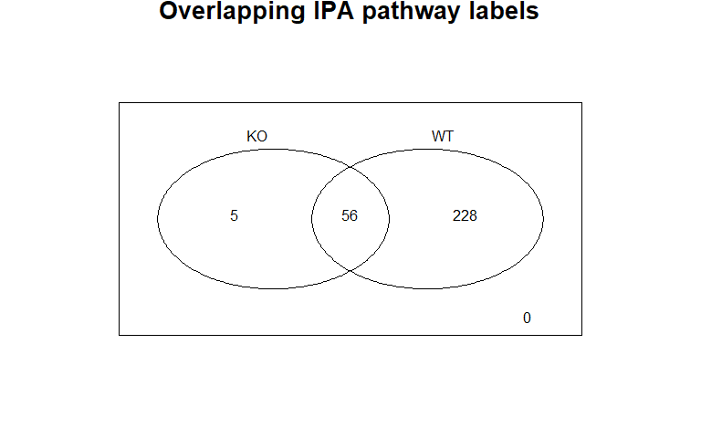

###IPA canonical meta Here we can see the overlap between the different labels in the IPA canonical output

```r
ShowExperimentdata(Object =IPA.object1 )
```

```
##                Groupnames Length
## Experiment_1 Canonical.KO     61
## Experiment_2 Canonical.WT    284
##                                                                                                                                                    file_location
## Experiment_1 C:/Users/ewoewi/Documents/Project9/Paper/GeneSetCluster/GeneSetCluster_1.0.1/GeneSetCluster/inst/extdata/MM10.IPA.KO.uGvsMac.Canonical_pathways.xls
## Experiment_2 C:/Users/ewoewi/Documents/Project9/Paper/GeneSetCluster/GeneSetCluster_1.0.1/GeneSetCluster/inst/extdata/MM10.IPA.WT.uGvsMac.Canonical_pathways.xls
```

```r
ShowMeta(Object =IPA.object1 )
```

```
##              source               type structure     organism       Groups
## Experiment_1    IPA Canonical_Pathways    SYMBOL org.Mm.eg.db Canonical.KO
## Experiment_2    IPA Canonical_Pathways    SYMBOL org.Mm.eg.db Canonical.WT
##              seperator Data cluster.method highlight order.group loaded
## Experiment_1         , List             NA        NA          NA   Auto
## Experiment_2         , List             NA        NA          NA   Auto
##                display mol.signature
## Experiment_1 Condensed           All
## Experiment_2 Condensed           All
```

### 1.4.3 IPA Combining and clustering canonical Gene-Sets

Here we combine and cluster the IPA output using kmeans.

```r
IPA.object2 <- CombineGeneSets(Object = IPA.object1,
                               display = "Expanded")
```

```
## [=========================================================]
```

```
## [<<<<            CombineGeneSets START               >>>>>]
```

```
## transforming all genes to upper case, make sure this doesnt change the data
```

```
## raw data has 634 genes
```

```
## Transformed data has 634 genes
```

```
## Combining experiments
```

```
## preparing expanded display
```

```
## calulating RR
```

```
## [<<<<<             CombineGeneSets END              >>>>>>]
```

```
## [=========================================================]
```

```
## [You may want to process ClusterGeneSets next.            ]
```

```r
IPA.object3 <- ClusterGeneSets(Object = IPA.object2,
                               clusters = 12,
                               method = "kmeans")
```

```
## [=========================================================]
```

```
## [<<<<            ClusterGeneSets START               >>>>>]
```

```
## Using all Gene sets
```

```
## Running kmeans
```

```
## Ordering pathway clusters
```

```
## [<<<<<             ClusterGeneSets END              >>>>>>]
```

```
## [=========================================================]
```

```
## [You may want to process HighlightGeneSets next.            ]
```

```
## [You may want to plot the results using PlotGeneSets next. ]
```

### 1.4.4 Highlighting genes

When running the data we can ask it wether a certain set of genes ar emore appearing in certain clusters than others. To view this we can take a gene set and highlight it in the data. In the plot an extra bar will appear where the higher the overlap the darker blue it becomes.

```r
#Highlighting Redox Genes
system.file("data", "Redox.genes.rda", package = "testdat")
```

```
## [1] ""
```

```r
IPA.object3.highlight <- HighlightGeneSets(Object = IPA.object3,
                                           highligt.genes = Redox.genes,
                                           name = "Ros")
```

```
## [=========================================================]
```

```
## [<<<<<             HighlightGeneSets start            >>>>>>]
```

```
## make sure that the structure of the highlight.genes is the same as the data
```

```
## transforming all highligt.genes to upper case, make sure this doesnt change the data
```

```
## raw data has 377 highligt.genes
```

```
## Transformed data has 377 highligt.genes
```

```
## Calculating overlap between pathways and highlight genes
```

```
## [<<<<<             HighlightGeneSets END              >>>>>>]
```

```
## [=========================================================]
```

### 1.4.5 Plot The IPA canonical RR with highlights clusters

These highlighted genes add a bar with highlight to the plot

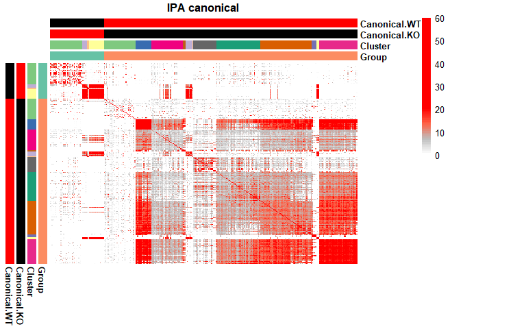

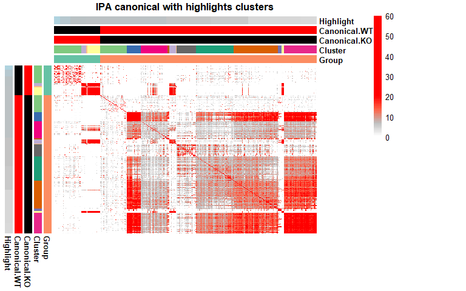

THis highlight can also be seen using ShowGeneSets. Note the ShowGeneSets returns a data.frame, use of head(), tail() etc to not overwhelm the console with data.

```
##                                                                    Pathways
## Canonical.WT.203                                            IL-22 Signaling
## Canonical.WT.227                                       Interferon Signaling
## Canonical.WT.243 Role of JAK family kinases in IL-6-type Cytokine Signaling
## Canonical.WT.268        Role of JAK1, JAK2 and TYK2 in Interferon Signaling
## Canonical.WT.278            Role of JAK2 in Hormone-like Cytokine Signaling
##                                                          Molecules
## Canonical.WT.203           SOCS3,AKT1,JAK1,MAPK3,IL10RB,AKT3,STAT1
## Canonical.WT.227 IFITM3,OAS1,JAK1,IFNGR1,STAT2,STAT1,IFITM2,IFNAR1
## Canonical.WT.243                 IL6ST,SOCS3,JAK1,MAPK3,IL6R,STAT1
## Canonical.WT.268                    JAK1,IFNGR1,STAT2,STAT1,IFNAR1
## Canonical.WT.278                SOCS3,JAK1,PTPN1,STAT1,SIRPA,SH2B1
##                        Groups               Type Ratio MoleculesCount
## Canonical.WT.203 Canonical.WT Canonical_Pathways 0.292              7
## Canonical.WT.227 Canonical.WT Canonical_Pathways 0.222              8
## Canonical.WT.243 Canonical.WT Canonical_Pathways 0.240              6
## Canonical.WT.268 Canonical.WT Canonical_Pathways 0.208              5
## Canonical.WT.278 Canonical.WT Canonical_Pathways 0.176              6
##                    GeneSets Canonical.KO Canonical.WT
## Canonical.WT.203 GeneSet264            0            1
## Canonical.WT.227 GeneSet288            0            1
## Canonical.WT.243 GeneSet304            0            1
## Canonical.WT.268 GeneSet329            0            1
## Canonical.WT.278 GeneSet339            0            1
##                                                                                  RR_name
## Canonical.WT.203                                            Canonical.WT_IL-22 Signaling
## Canonical.WT.227                                       Canonical.WT_Interferon Signaling
## Canonical.WT.243 Canonical.WT_Role of JAK family kinases in IL-6-type Cytokine Signaling
## Canonical.WT.268        Canonical.WT_Role of JAK1, JAK2 and TYK2 in Interferon Signaling
## Canonical.WT.278            Canonical.WT_Role of JAK2 in Hormone-like Cytokine Signaling
##                  cluster mean.RR.cl sum.RR.cl Highlight Highlight.mean
## Canonical.WT.203      10    62.0392  1550.981 0.4285714       0.512381
## Canonical.WT.227      10    62.0392  1550.981 0.5000000       0.512381
## Canonical.WT.243      10    62.0392  1550.981 0.3333333       0.512381
## Canonical.WT.268      10    62.0392  1550.981 0.8000000       0.512381
## Canonical.WT.278      10    62.0392  1550.981 0.5000000       0.512381
```

### 1.4.6 Distance calculations using user supplied combinations functions

calcuating the distance between Gene-Sets is by default by calcuting the RR. However in certain cases the user wants to use a different function to comine the data. The function alows to use a user supplied functions. e.g. the jaccard similarity index can be used, this calculated the overlap between Gene-sets. Jaccard is quite suitable for larger Gene-Sets but biased in smaller Gene-Sets.

```r
jaccard <- function(A,B)
{
  #The Jaccard similarity index (sometimes called the Jaccard similarity coefficient) compares members
  #for two sets to see which members are shared and which are distinct.
  #It's a measure of similarity for the two sets of data, with a range from 0% to 100%.
  #The higher the percentage, the more similar the two populations.

  M <- sum(as.vector(A) == 1 & as.vector(B) == 1)
  A.c <- sum(as.vector(A) == 1 & as.vector(B) == 0)
  B.c <- sum(as.vector(A) == 0 & as.vector(B) == 1)
  J <- M/(A.c+B.c+M)
  return(J)
}


IPA.Object.J <- CombineGeneSets(Object = IPA.object1, combineMethod = "Jaccard", combineMethod.supplied = jaccard)
```

```
## [=========================================================]
```

```
## [<<<<            CombineGeneSets START               >>>>>]
```

```
## transforming all genes to upper case, make sure this doesnt change the data
```

```
## raw data has 634 genes
```

```
## Transformed data has 634 genes
```

```
## Combining experiments
```

```
## preparing condensed display
```

```
## calulating Jaccard
```

```
## [<<<<<             CombineGeneSets END              >>>>>>]
```

```
## [=========================================================]
```

```
## [You may want to process ClusterGeneSets next.            ]
```

```r
IPA.Object.J <- ClusterGeneSets(Object = IPA.Object.J,
                                                clusters = 4,
                                                method = "kmeans",
                                                order = "group")
```

```
## [=========================================================]
```

```
## [<<<<            ClusterGeneSets START               >>>>>]
```

```
## Using all Gene sets
```

```
## Running kmeans
```

```
## Ordering pathway clusters
```

```
## [<<<<<             ClusterGeneSets END              >>>>>>]
```

```
## [=========================================================]
```

```
## [You may want to process HighlightGeneSets next.            ]
```

```
## [You may want to plot the results using PlotGeneSets next. ]
```

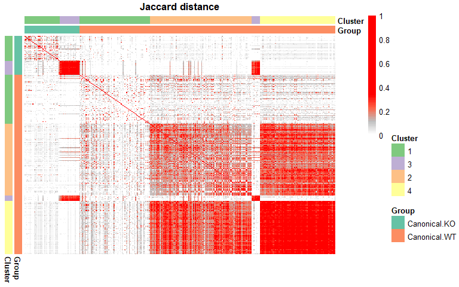

```r
PlotGeneSets(Object = IPA.Object.J, fontsize =5,
            legend = T,
            annotation.mol=F,
            main="Jaccard distance", RR.max = 50)
```

## 1.5 Loading the IPA functional annotations

Using GeneSetCluster to load Functional annotations is possible by adding Functional_annotations to type. Specify in the loader that these are functional annotations and set the Pvalue cutoff accordingly. Using default settings Canonical pathways are exported with -log10 transformed Pvalues, meaning the larger is more significant, while functional annotations are exported with untransformed pvalues.

```r
################################################
#-------IPA on Functional_annotations----------#
################################################


functional.files <- IPA.files[grep("Functional", IPA.files)]

IPA.Functional.object1 <- LoadGeneSets(file_location = functional.files,
                                 groupnames= c("Functional.KO", "Functional.WT"),
                                 P.cutoff = 0.05,
                                 Mol.cutoff = 5,
                                 Source = "IPA",
                                 type = "Functional_annotations",
                                 structure = "SYMBOL",
                                 seperator = ",")
```

```
## [=========================================================]
```

```
## [<<<<            LoadGeneSets START                  >>>>>]
```

```
## Loading data from C:/Users/ewoewi/Documents/Project9/Paper/GeneSetCluster/GeneSetCluster_1.0.1/GeneSetCluster/inst/extdata/MM10.IPA.KO.uGvsMac.Functional_annotations.xls
```

```
## Loading data from C:/Users/ewoewi/Documents/Project9/Paper/GeneSetCluster/GeneSetCluster_1.0.1/GeneSetCluster/inst/extdata/MM10.IPA.WT.uGvsMac.Functional_annotations.xls
```

```
## Loading IPA Functional_annotations
```

```
## [<<<<<               LoadGeneSets END               >>>>>>]
```

```
## [=========================================================]
```

```
## [You may want to process CombineGeneSets next.            ]
```

```
## [or merge objects using MergeObjects                     ]
```

```
## [or select certain types from objects using ManageGeneSets]
```

### 1.5.1 Plot Overlap of functions labels

Using VennDiagram we can see the overlap between the different labels in the IPA functional output. Many functional annotations labels are shared while the Canonical Pathways showed different results.

```r
VennDiagram(n_groups = 2,
               Group1 = as.character(IPA.Functional.object1@Data$Functional.KO$Pathways),
               Group2 =as.character(IPA.Functional.object1@Data$Functional.WT$Pathways),
               names_groups = c("KO", "WT"),
               main = "Overlapping IPA functions labels",legend = F, percentage = F )
```

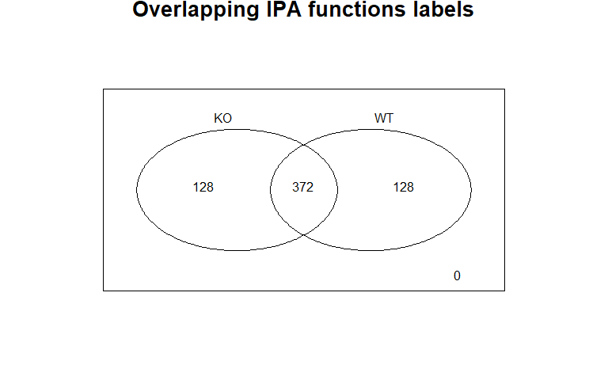

###IPA functional meta Here we can see the overlap between the different labels in the IPA functional output. They should reflect the experiments accordingly.

```r
ShowExperimentdata(Object =IPA.Functional.object1 )
```

```
##                 Groupnames Length
## Experiment_1 Functional.KO    500
## Experiment_2 Functional.WT    500
##                                                                                                                                                        file_location
## Experiment_1 C:/Users/ewoewi/Documents/Project9/Paper/GeneSetCluster/GeneSetCluster_1.0.1/GeneSetCluster/inst/extdata/MM10.IPA.KO.uGvsMac.Functional_annotations.xls
## Experiment_2 C:/Users/ewoewi/Documents/Project9/Paper/GeneSetCluster/GeneSetCluster_1.0.1/GeneSetCluster/inst/extdata/MM10.IPA.WT.uGvsMac.Functional_annotations.xls
```

```r
ShowMeta(Object = IPA.Functional.object1 )
```

```
##              source                   type structure     organism
## Experiment_1    IPA Functional_annotations    SYMBOL org.Mm.eg.db
## Experiment_2    IPA Functional_annotations    SYMBOL org.Mm.eg.db
##                     Groups seperator Data cluster.method highlight
## Experiment_1 Functional.KO         , List             NA        NA
## Experiment_2 Functional.WT         , List             NA        NA
##              order.group loaded   display mol.signature
## Experiment_1          NA   Auto Condensed           All
## Experiment_2          NA   Auto Condensed           All
```

### 1.5.2 IPA Combining and clustering functional Gene-Sets

This functional object works the same as the rest.

```r
IPA.Functional.object2 <- CombineGeneSets(Object = IPA.Functional.object1,
                                          display = "Expanded")
```

```
## [=========================================================]
```

```
## [<<<<            CombineGeneSets START               >>>>>]
```

```
## transforming all genes to upper case, make sure this doesnt change the data
```

```
## raw data has 1769 genes
```

```
## Transformed data has 1769 genes
```

```
## Combining experiments
```

```
## preparing expanded display
```

```
## calulating RR
```

```
## [<<<<<             CombineGeneSets END              >>>>>>]
```

```
## [=========================================================]
```

```
## [You may want to process ClusterGeneSets next.            ]
```

```r
IPA.Functional.object3 <- ClusterGeneSets(Object = IPA.Functional.object2,
                               clusters = 8,
                               method = "kmeans")
```

```
## [=========================================================]
```

```
## [<<<<            ClusterGeneSets START               >>>>>]
```

```
## Using all Gene sets
```

```
## Running kmeans
```

```
## Ordering pathway clusters
```

```
## [<<<<<             ClusterGeneSets END              >>>>>>]
```

```
## [=========================================================]
```

```
## [You may want to process HighlightGeneSets next.            ]
```

```
## [You may want to plot the results using PlotGeneSets next. ]
```

### 1.5.3 Plot The IPA functional RR

Plotting the different Pathways shows that it works the same to investigate the different clusters.

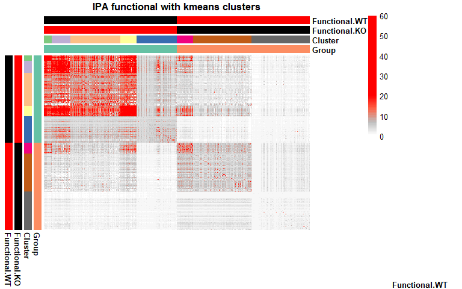

## 1.6 Merging the canonical pathways and functional annotations

```r
Ipa.merged.object1 <- MergeObjects(Object.1 =IPA.object1,
                                    Object.2 = IPA.Functional.object1)
```

```
## [=========================================================]
```

```
## [<<<<            MergeObjects START                 >>>>>]
```

```
## merging data sets
```

```
## [<<<<<               MergeObjects END              >>>>>>]
```

```
## [=========================================================]
```

```r
ShowExperimentdata(Object =Ipa.merged.object1 )
```

```
##                 Groupnames Length
## Experiment_1  Canonical.KO     61
## Experiment_2  Canonical.WT    284
## Experiment_3 Functional.KO    500
## Experiment_4 Functional.WT    500
##                                                                                                                                                        file_location
## Experiment_1     C:/Users/ewoewi/Documents/Project9/Paper/GeneSetCluster/GeneSetCluster_1.0.1/GeneSetCluster/inst/extdata/MM10.IPA.KO.uGvsMac.Canonical_pathways.xls
## Experiment_2     C:/Users/ewoewi/Documents/Project9/Paper/GeneSetCluster/GeneSetCluster_1.0.1/GeneSetCluster/inst/extdata/MM10.IPA.WT.uGvsMac.Canonical_pathways.xls
## Experiment_3 C:/Users/ewoewi/Documents/Project9/Paper/GeneSetCluster/GeneSetCluster_1.0.1/GeneSetCluster/inst/extdata/MM10.IPA.KO.uGvsMac.Functional_annotations.xls
## Experiment_4 C:/Users/ewoewi/Documents/Project9/Paper/GeneSetCluster/GeneSetCluster_1.0.1/GeneSetCluster/inst/extdata/MM10.IPA.WT.uGvsMac.Functional_annotations.xls
```

```r
ShowMeta(Object = Ipa.merged.object1 )
```

```
##              source                   type structure     organism
## Experiment_1    IPA     Canonical_Pathways    SYMBOL org.Mm.eg.db
## Experiment_2    IPA     Canonical_Pathways    SYMBOL org.Mm.eg.db
## Experiment_3    IPA Functional_annotations    SYMBOL org.Mm.eg.db
## Experiment_4    IPA Functional_annotations    SYMBOL org.Mm.eg.db
##                     Groups seperator Data cluster.method highlight
## Experiment_1  Canonical.KO         , List             NA        NA
## Experiment_2  Canonical.WT         , List             NA        NA
## Experiment_3 Functional.KO         , List             NA        NA
## Experiment_4 Functional.WT         , List             NA        NA
##              order.group loaded   display mol.signature
## Experiment_1          NA   Auto Condensed           All
## Experiment_2          NA   Auto Condensed           All
## Experiment_3          NA   Auto Condensed           All
## Experiment_4          NA   Auto Condensed           All
```

### 1.6.1 Combine and cluster merged data

Following merging the pipeline combines and clusters the results. Of note here is of course the time it takes growths exponentially with larger datasets, so the merged data takes longer than the seperate data sets.

```r
Ipa.merged.object2 <- CombineGeneSets(Object = Ipa.merged.object1,
                                      display="Expanded")
```

```
## [=========================================================]
```

```
## [<<<<            CombineGeneSets START               >>>>>]
```

```
## transforming all genes to upper case, make sure this doesnt change the data
```

```
## raw data has 1772 genes
```

```
## Transformed data has 1772 genes
```

```
## Combining experiments
```

```
## preparing expanded display
```

```
## calulating RR
```

```
## [<<<<<             CombineGeneSets END              >>>>>>]
```

```
## [=========================================================]
```

```
## [You may want to process ClusterGeneSets next.            ]
```

```r
Ipa.merged.object3 <- ClusterGeneSets(Object = Ipa.merged.object2,
                                          clusters = 14,
                                          method = "kmeans")
```

```
## [=========================================================]
```

```
## [<<<<            ClusterGeneSets START               >>>>>]
```

```
## Using all Gene sets
```

```
## Running kmeans
```

```
## Ordering pathway clusters
```

```
## [<<<<<             ClusterGeneSets END              >>>>>>]
```

```
## [=========================================================]
```

```
## [You may want to process HighlightGeneSets next.            ]
```

```
## [You may want to plot the results using PlotGeneSets next. ]
```

### 1.6.2 Merged Data in Object3

Now the data sets are merged and compared. These are completely normal PathwayObjects now. So we can also highlight the object same as we done before.

```r
Ipa.merged.object3.highlight <- HighlightGeneSets(Object = Ipa.merged.object3, highligt.genes = Redox.genes, name = "Ros")
```

```
## [=========================================================]
```

```
## [<<<<<             HighlightGeneSets start            >>>>>>]
```

```
## make sure that the structure of the highlight.genes is the same as the data
```

```
## transforming all highligt.genes to upper case, make sure this doesnt change the data
```

```
## raw data has 377 highligt.genes
```

```
## Transformed data has 377 highligt.genes
```

```
## Calculating overlap between pathways and highlight genes
```

```
## [<<<<<             HighlightGeneSets END              >>>>>>]
```

```
## [=========================================================]
```

### 1.6.3 Plot The IPA merged RR

In the heatmap with the expanded display clearly shows the difference between the different clusters.

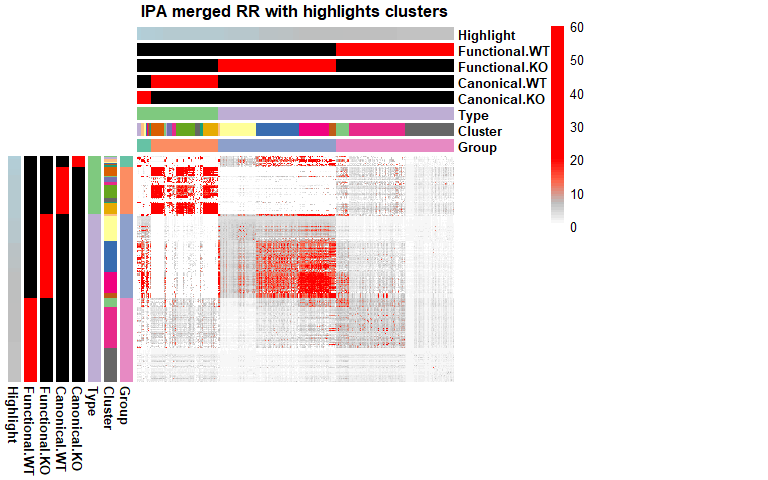

## 1.7 Export the combined pathways and RR

Exporting the files is done using the WriteGeneSets. It writes it in the folder assigned to file_location and it takes the name of Name and writes it into a CSV file with seperation of “;”, to make it readable by Excel.

```r
WriteGeneSets(Object = Ipa.merged.object3.highlight, file_location = getwd(), name = "Ipa.merged.object3.highlight", write = "Both")
```

## 1.8 Creating object with custom table

When data wasnt run in GREAT or IPA the pipeline can still be used. In fact it doesnt neccesary need to be proper pathways. The thing the code needs is a group, a name, and name content. Plus some meta info. It is possible to simulate a dataset.

### 1.8.1 Creating random pathway data

Simulation starts with generating a random data set. Assign the names as Pathway_1 etc. With the genes inside just being Gene_1 to Gene_200.

```r
Test.object <- matrix(data = NA, nrow = 50, ncol = 3)
colnames(Test.object) <- c("Pathways", "Genes", "Group")
Test.object[,"Pathways"] <- paste("Pathway", 1:nrow(Test.object), sep = "_")
Test.object[1:25,"Group"] <- "Group1"
Test.object[26:50,"Group"] <- "Group2"


#Create a random amount of genes per pathway
random.gene <- function()
{
  genenames <- paste("Gene", 1:200, sep = "_")#this gives 200 gene names
  genes <- round(runif(n = runif(n = 1,min =  7,max = 20), min = 1, max = 200), digits = 0)#This gives between 7 and 20 random whole numbers
  genes <- unique(genes)#remove duplicate numbers
  genes <- genenames[genes]#get random genesnames
  return(genes)
}

for(i in 1:nrow(Test.object))
{
  Test.object[i, "Genes"] <- paste(random.gene(), collapse=",")#Collapse the genes into a string
}

head(Test.object)
```

```
##      Pathways
## [1,] "Pathway_1"
## [2,] "Pathway_2"
## [3,] "Pathway_3"
## [4,] "Pathway_4"
## [5,] "Pathway_5"
## [6,] "Pathway_6"
##      Genes
## [1,] "Gene_24,Gene_182,Gene_43,Gene_1,Gene_100,Gene_152,Gene_103,Gene_146,Gene_87,Gene_39"
## [2,] "Gene_57,Gene_43,Gene_29,Gene_100,Gene_117,Gene_130,Gene_33,Gene_104,Gene_62,Gene_69,Gene_74,Gene_86,Gene_68,Gene_54"
## [3,] "Gene_89,Gene_151,Gene_61,Gene_74,Gene_182,Gene_192,Gene_34,Gene_43,Gene_79,Gene_121,Gene_161,Gene_21"
## [4,] "Gene_200,Gene_165,Gene_123,Gene_140,Gene_53,Gene_176,Gene_19,Gene_145,Gene_192,Gene_134,Gene_90,Gene_180,Gene_34"
## [5,] "Gene_53,Gene_33,Gene_15,Gene_3,Gene_13,Gene_169,Gene_35,Gene_173,Gene_78,Gene_50,Gene_28,Gene_77,Gene_19,Gene_118,Gene_10,Gene_174,Gene_32,Gene_76"
## [6,] "Gene_112,Gene_116,Gene_167,Gene_165,Gene_70,Gene_154,Gene_82,Gene_164,Gene_171,Gene_10"
##      Group
## [1,] "Group1"
## [2,] "Group1"
## [3,] "Group1"
## [4,] "Group1"
## [5,] "Group1"
## [6,] "Group1"
```

### 1.8.2 Creating object with custom table

This simulated dataset is then inputted into the ObjectCreator to generate a proper PathwayObject.

```r
Test.object1 <- ObjectCreator(Pathways = Test.object[,1],
                              Molecules = Test.object[,2],
                              Groups = Test.object[,3],
                              Source = "Random",
                              Type = "Random",
                              structure = "SYMBOL",organism ="Org.HS.eg.db",
                              sep = ",")#neccesay to seperate the different genes for combinations.
```

```
## [=========================================================]
```

```
## [<<<<            ObjectCreator START                 >>>>>]
```

```
## [<<<<<               ObjectCreator END              >>>>>>]
```

```
## [=========================================================]
```

```
## [You may want to process CombineGeneSets next.            ]
```

```
## [or merge objects using MergeObjects                     ]
```

```
## [or select certain types from objects using ManageGeneSets]
```

```r
ShowExperimentdata(Object = Test.object1)
```

```
##              Groupnames Length file_location
## Experiment_1     Group1     25            NA
## Experiment_2     Group2     25            NA
```

```r
ShowMeta(Object = Test.object1)
```

```
##              source   type structure     organism seperator Data
## Experiment_1 Random Random    SYMBOL Org.HS.eg.db         ,   DF
## Experiment_2 Random Random    SYMBOL Org.HS.eg.db         ,   DF
##              cluster.method highlight order.group loaded   display
## Experiment_1             NA        NA          NA Manual Condensed
## Experiment_2             NA        NA          NA Manual Condensed
##              mol.signature
## Experiment_1           All
## Experiment_2           All
```

### 1.8.3 Creating Combine and clustering custom object

The combining and clustering works exactly the same as autoloaded objects.

```r
Test.object2 <- CombineGeneSets(Object = Test.object1)
```

```
## [=========================================================]
```

```
## [<<<<            CombineGeneSets START               >>>>>]
```

```
## transforming all genes to upper case, make sure this doesnt change the data
```

```
## raw data has 194 genes
```

```
## Transformed data has 194 genes
```

```
## Combining experiments
```

```
## preparing condensed display
```

```
## calulating RR
```

```
## [<<<<<             CombineGeneSets END              >>>>>>]
```

```
## [=========================================================]
```

```
## [You may want to process ClusterGeneSets next.            ]
```

```r
Test.object3 <- ClusterGeneSets(Object = Test.object2,
                                                clusters = 4,
                                                method = "kmeans",
                                                order = "group")
```

```
## [=========================================================]
```

```
## [<<<<            ClusterGeneSets START               >>>>>]
```

```
## Using all Gene sets
```

```
## Running kmeans
```

```
## Ordering pathway clusters
```

```
## [<<<<<             ClusterGeneSets END              >>>>>>]
```

```
## [=========================================================]
```

```
## [You may want to process HighlightGeneSets next.            ]
```

```
## [You may want to plot the results using PlotGeneSets next. ]
```

### 1.8.4 Plotting custom Object

The plotting works the same as any other object3. Note there are few clusters visible because the data is random.

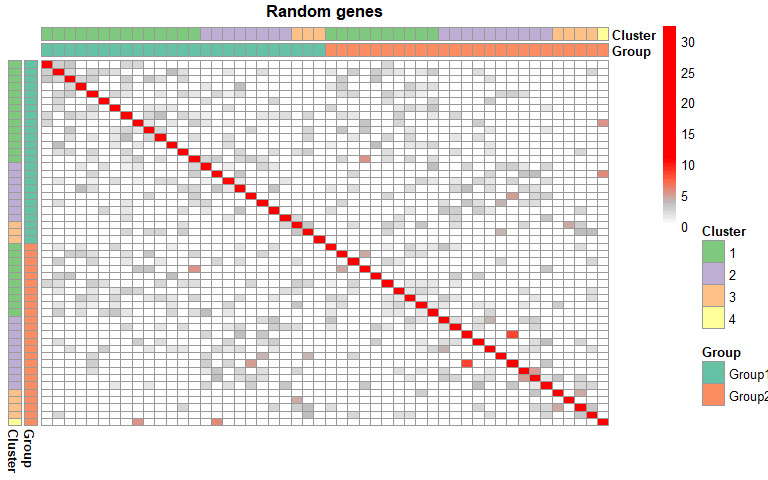

```r
PlotGeneSets(Object = Test.object3, fontsize =5,
            legend = T,
            annotation.mol=F,
            main="Random genes", RR.max = 50)
```